# imrs_saude

Autogenerated data summary from dataMaid

2023-09-26 01:38:39

# Data report overview

The dataset examined has the following dimensions:

| Feature | Result |
| --- | --- |
| Number of observations | 853 |
| Number of variables | 24 |

### Checks performed

The following variable checks were performed, depending on the data type of each variable:

|  | character | factor | labelled | haven labelled | numeric | integer | logical | Date |
| --- | --- | --- | --- | --- | --- | --- | --- | --- |
| Identify miscoded missing values | × | × | × | × | × | × |  | × |
| Identify prefixed and suffixed whitespace | × | × | × | × |  |  |  |  |
| Identify levels with < 6 obs. | × | × | × | × |  |  |  |  |
| Identify case issues | × | × | × | × |  |  |  |  |
| Identify misclassified numeric or integer variables | × | × | × | × |  |  |  |  |
| Identify outliers |  |  |  |  | × | × |  | × |

Please note that all numerical values in the following have been rounded to 2 decimals.

# Summary table

|  | Variable class | # unique values | Missing observations | Any problems? |
| --- | --- | --- | --- | --- |
| IBGE7 | numeric | 853 | 0.00 % |  |
| S_TXBRUTAMORT | numeric | 853 | 0.00 % | × |
| S_TXBRUTAMORT_t_1 | numeric | 845 | 0.00 % | × |
| S_TXBRUTAMORTPAD | numeric | 853 | 0.00 % | × |
| S_TXMOISQCOR45A59 | numeric | 849 | 0.00 % | × |
| S_TXMOAVC45A59 | numeric | 851 | 0.00 % | × |
| S_TXMOATRA15A29 | numeric | 845 | 0.00 % | × |
| S_TXMOHOMI | numeric | 807 | 3.99 % | × |

# Variable list

## IBGE7

| Feature | Result |
| --- | --- |
| Variable type | numeric |
| Number of missing obs. | 0 (0 %) |
| Number of unique values | 853 |
| Median | 3137304 |
| 1st and 3rd quartiles | 3119500; 3154903 |
| Min. and max. | 3100104; 3172202 |
| No. zeros | 0 |
| No. outliers | 0 |

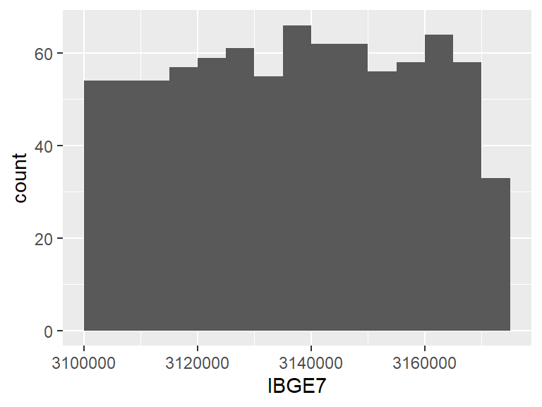

## S_TXBRUTAMORT

[output not shown]

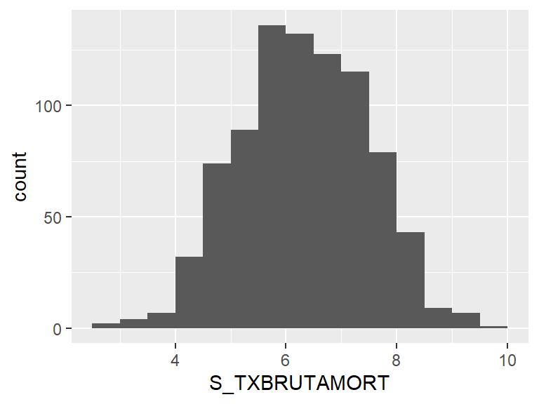

- Note that the following possible outlier values were detected: "2.75", "2.87", "3.19", "3.25", "3.38", "3.39", "3.51", "3.53", "9.93".

## S_TXBRUTAMORT_t_1

| Feature | Result |
| --- | --- |
| Variable type | numeric |
| Number of missing obs. | 0 (0 %) |
| Number of unique values | 845 |
| Median | 6.53 |
| 1st and 3rd quartiles | 5.59; 7.53 |
| Min. and max. | 2; 12 |
| No. zeros | 0 |
| No. outliers | 12 |

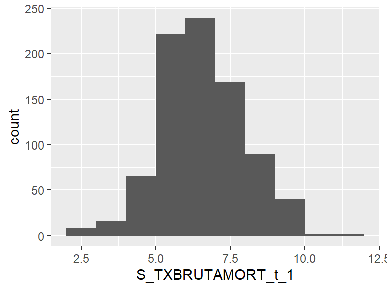

- Note that the following possible outlier values were detected: "2", "10.75", "11.22", "12".

## S_TXBRUTAMORTPAD

[output not shown]

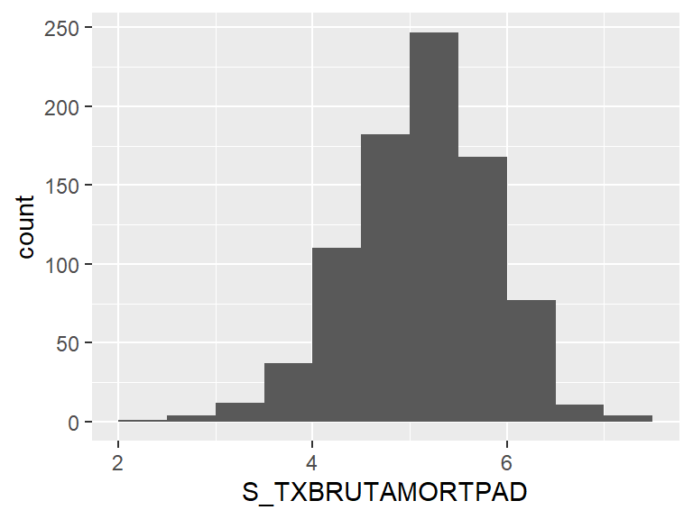

- Note that the following possible outlier values were detected: "2.45", "2.64", "2.67", "2.78", "6.6", …, "6.95", "7.08", "7.12", "7.22", "7.43" (5 values omitted).

## S_TXMOISQCOR45A59

[output not shown]

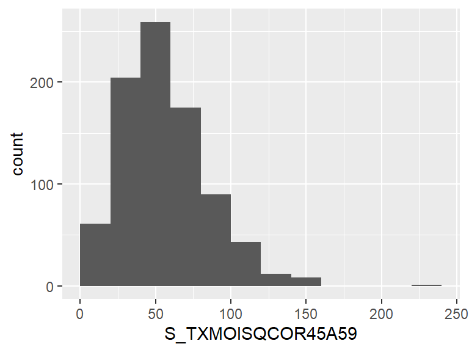

- Note that the following possible outlier values were detected: "0", "141.67", "142.48", "146.92", "149.17", "150.58", "151.29", "156.14", "159.7", "228.58".

## S_TXMOAVC45A59

| Feature | Result |
| --- | --- |
| Variable type | numeric |
| Number of missing obs. | 0 (0 %) |
| Number of unique values | 851 |
| Median | 51.17 |
| 1st and 3rd quartiles | 38.96; 63.31 |
| Min. and max. | 0; 198.34 |
| No. zeros | 3 |
| No. outliers | 22 |

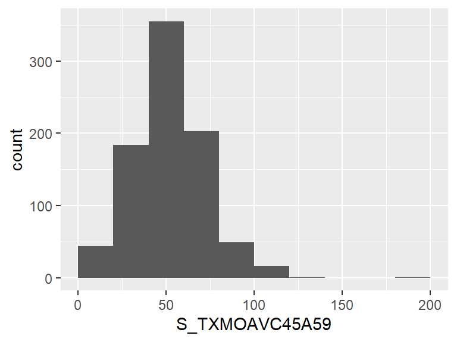

- Note that the following possible outlier values were detected: "0", "102.13", "102.89", "103.04", "103.31", …, "116.3", "116.76", "117.52", "138.83", "198.34" (9 values omitted).

## S_TXMOATRA15A29

| Feature | Result |
| --- | --- |
| Variable type | numeric |
| Number of missing obs. | 0 (0 %) |
| Number of unique values | 845 |
| Median | 23.2 |
| 1st and 3rd quartiles | 16.76; 31.12 |
| Min. and max. | 0; 103.64 |
| No. zeros | 9 |
| No. outliers | 29 |

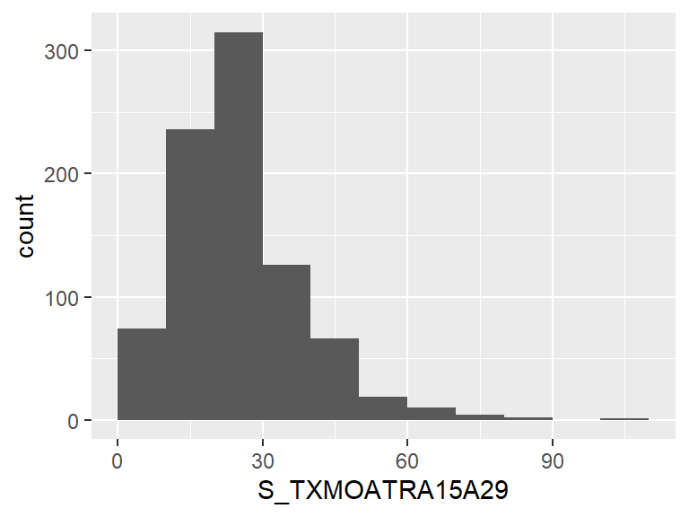

- Note that the following possible outlier values were detected: "0", "3.11", "3.16", "3.64", "3.9", …, "74.06", "79.98", "86.05", "86.96", "103.64" (10 values omitted).

Report generation information:

- Created by: Could not determine from system (username: Unknown)
- Report creation time: ter set 26 2023 01:38:39
- Report was run from directory: `C:/Users/caios/OneDrive/Documentos/GitHub/Critica_Datamaid`
- dataMaid v1.4.1 [Pkg: 2021-10-08 from CRAN (R 4.2.3)]
- R version 4.2.2 (2022-10-31 ucrt).
- Platform: x86_64-w64-mingw32/x64 (64-bit)(Windows 10 x64 (build 22621)).
- Function call: `makeDataReport(data = imrs_saude, output = "html", replace = TRUE, summaries = setSummaries(character = defaultCharacterSummaries(add = c("countZeros", "countOutliers")), factor = defaultFactorSummaries(add = c("countZeros", "countOutliers")), labelled = defaultLabelledSummaries(add = c("countZeros", "countOutliers")), numeric = defaultNumericSummaries(add = c("countZeros", "countOutliers")), integer = defaultIntegerSummaries(add = c("countZeros", "countOutliers")), logical = defaultLogicalSummaries(add = c("countZeros", "countOutliers"))))`